# Multivariate Analysis Lecture 14: QDA and Decision Theory

Zhaoxia Yu

Professor, Department of Statistic

2026-05-31

```r
knitr::opts_chunk$set(echo = TRUE)
library(tidyr) #the pipe (%>%) tool is extremely useful
library(MASS)
library(ggplot2)
library(kableExtra)
library("gridExtra")
library(klaR) #visualize lda and qda
library(knitr)
```

# Outline

- Review of LDA
- QDA
- Decision theory
  - Equal costs
  - Unequal costs

# Review of LDA

## Linear Discrminant Analysis

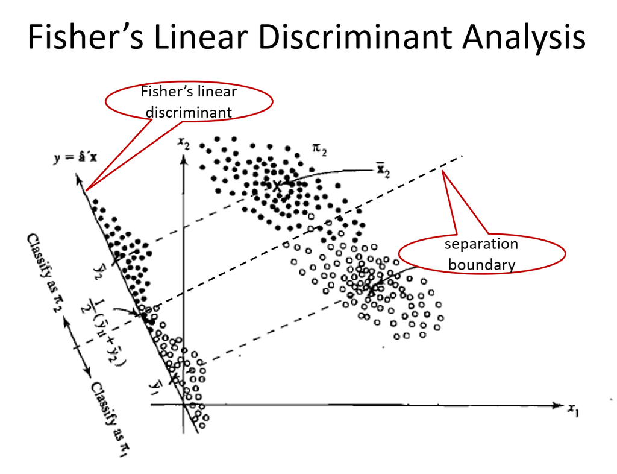

## FLDA: Maximum Separability for Two-Class Problems

- The maximization problem is
  $$\operatorname*{argmax}_a \frac{a^T(\bar {\mathbf X}_1 - \bar {\mathbf X}_2)(\bar {\mathbf X}_1 - \bar {\mathbf X}_2)^Ta}{a^T \boldsymbol \Sigma a}$$
- Use an argument similar to PCA, such $a$ is the first eigenvector of $\boldsymbol \Sigma ^{-1}(\bar {\mathbf X}_1 - \bar {\mathbf X}_2)(\bar {\mathbf X}_1 - \bar {\mathbf X}_2)^T$.
- We can show that $a=\mathbf S_p^{-1}(\bar {\mathbf X}_1 - \bar {\mathbf X}_2)$.
- The linear function
  $$f(x)=a^T x \mbox{ where } a=\mathbf S_p^{-1}(\bar {\mathbf X}_1 - \bar {\mathbf X}_2)$$
  is called Fisher’s linear discriminant function.

## Allocate New Observations

- Consider an observation $X_0$. We compute
  $$f(X_0)=a^T X_0$$
  where $a=\mathbf S_p^{-1}(\bar {\mathbf X}_1 - \bar {\mathbf X}_2)$
- Let
  $$m=a^T \frac{\bar {\mathbf X}_1 + \bar {\mathbf X}_2}{2}=\boldsymbol (\bar {\mathbf X}_1 - \bar {\mathbf X}_2)^T \mathbf S_p^{-1}\frac{\bar {\mathbf X}_1 + \bar {\mathbf X}_2}{2}$$
- Allocate $X_0$ to
  - class 1 if $f(X_0)>m$
  - class 2 if $f(x_0)<m$

## g-Class Problems

- Measure separation using F statistic
  $$\begin{aligned}
  F(a) &= \frac{MSB}{MSW}=\frac{SSB/(g-1)}{SSW/(n-g)}\\
  &= \frac{\sum_{i=1}^g n_i (\bar Y_{i.}^{(1)} -\bar Y_{..}^{(1)})^2/(g-1)}{\sum_{i=1}^g (n_i-1)S_{Y_i^{(1)}}^2/(n-g)}\\
  &=\frac{a^T \sum n_i (\bar X_{i.} -\bar X_{..})(\bar X_{i.}-\bar X_{..})^T a}{a^T \sum_{i=1}^g\sum_{j=1}^{n_i} (X_{ij} -\bar X_{i.})(X_{ij}-\bar X_{i.})^T a}\frac{n-g}{g-1}\\
  &= \frac{a^T \mathbf B a}{a^T \mathbf W a}\frac{n-g}{g-1}
  \end{aligned}$$
  where $n=\sum_{i=1}^g n_i$, $\mathbf B$ is the between-group sample covariance matrix, and $\mathbf W$ is the within-group sample covariance matrix.

## Linear Discriminants

- The first linear discriminant is the linear function that maximizes $F(a)$. It can also be shown that the first linear discriminant is given by the first eigenvector of $\mathbf W ^{-1} \mathbf B$, i.e.,
  $$Y_{ij}^{(1)}=\gamma_1^T X_{ij}$$
  where $\gamma_1$ is the first eigenvector of $\mathbf W ^{-1} \mathbf B$.
- Similarly, for $k=1, \cdots, rank(\mathbf B)$, the $k$th linear discriminant is given by the $k$th eigenvector of $\mathbf W ^{-1} \mathbf B$
- $$Y_{ij}^{(k)}=\gamma_k^T X_{ij}$$

## Use the Linear Discriminants

- Let $X_0$ be a new observation. We allocate it to the group with the minimum distance defined by the Euclidean distance in space spanned by the linear discriminants.
- Calculate $Y_0^{(k)}=\gamma_k^T X_0$, the projection of $X_0$ to the $k$th linear discriminant for $k=1, \cdots, rank(B)$.
- Calculate the distance between $(Y_0^{(1)}, \cdots, Y_0^{(rank(B))})$ and $(\bar Y_{i.}^{(1)}, \cdots, \bar Y_{i.}^{(rank(B))})$

$$D^2(X_0, i) = \sum_{k=1}^{rank(B)} [Y_0^{(k)} - \bar Y_{i.}^{(k)}]^2$$

- Allocate $X_0$ to $\operatorname*{argmin}_i D^2(X_0, i)$.

# Quadratic DA (QDA)

## QDA for Two-Class Problems

- The LDA can be derived using likelihood functions under the assumptions
  1. Multivariate normal
  2. Equal covariance matrix
- The assumption of equal covariance matrix is not always a good approximation to the true covariance matrices
- If we relax this assumption, we will have QDA

## QDA for Two-Class Problems

- Let’s consider a two-class classification problem with $n_1$ and $n_2$ observations in classes 1 and 2, respectively.
- Suppose we have two independent random samples
  - Sample 1: $X_{1j}\overset{iid}\sim N(\mathbf \mu_1, \boldsymbol \Sigma_1)$, where $j=1, \cdots, n_1$
  - Sample 2: $X_{2j}\overset{iid}\sim N(\mathbf \mu_2, \boldsymbol \Sigma_2)$, where $j=1, \cdots, n_2$
- Sample mean vectors:
  $$\bar {\mathbf X}_1=\frac{1}{n_1}\sum_{j=1}^{n_1}X_{1j},
  \bar {\mathbf X}_2=\frac{1}{n_2}\sum_{j=1}^{n_2}X_{2j}$$
- Remark: the sample mean vectors are the MLE of the corresponding mean vectors

## QDA for Two-Class Problems

- MLE of covariance matrices
  $$\hat {\boldsymbol\Sigma}_1 = \frac{n_1-1}{n_1}S_1, \hat {\boldsymbol\Sigma}_2 = \frac{n_2-1}{n_2}S_2$$
  where $S_i$ is the sample covariance matrix for sample $i$.
- Likelihood functions
  $$\begin{aligned}
  L_1(\boldsymbol \mu_1, \boldsymbol \Sigma_1) \propto |\boldsymbol\Sigma_1|^{-1/2} exp\{-\frac{1}{2} (x-\boldsymbol \mu_1)^T \boldsymbol \Sigma_1^{-1} (x-\boldsymbol \mu_1)\}\\
  L_2(\boldsymbol \mu_2, \boldsymbol \Sigma_2) \propto |\boldsymbol\Sigma_2|^{-1/2} exp\{-\frac{1}{2} (x-\boldsymbol \mu_2)^T \boldsymbol \Sigma_2^{-1} (x-\boldsymbol \mu_2)\}
  \end{aligned}$$

## QDA for Two-Class Problems

- We can either check whether the ratio is greater than one or check whether the difference of log-likelihood is positive.

$$l_1 - l_2=-\frac{1}{2}log(\frac{|\boldsymbol\Sigma_1|}{|\boldsymbol\Sigma_2|}) - \frac{1}{2} [(x-\boldsymbol \mu_1)^T \boldsymbol \Sigma_1^{-1} (x-\boldsymbol \mu_1) - (x-\boldsymbol \mu_2)^T \boldsymbol \Sigma_2^{-1} (x-\boldsymbol \mu_2)]$$

- The classification boundary is given by $l_1-l_2=0$, i.e.,

$$(x-\boldsymbol \mu_1)^T \boldsymbol \Sigma_1^{-1} (x-\boldsymbol \mu_1) - (x-\boldsymbol \mu_2)^T \boldsymbol \Sigma_2^{-1} (x-\boldsymbol \mu_2) = log(\frac{|\boldsymbol\Sigma_2|}{|\boldsymbol\Sigma_1|})$$

- It is quadratic!

## QDA for Two-Class Problems

- Replace unknown parameters with estimate, we have the classification rule: allocate $x$ to class 1 if

$$\begin{align}
&(x-\bar {\mathbf X}_1)^T \mathbf S _1^{-1} (x-\bar {\mathbf X}_1) - (x-\bar {\mathbf X}_2)^T \mathbf S_2^{-1} (x-\bar {\mathbf X}_2)\\ & < log(\frac{|\mathbf S_2|}{|\mathbf S_1|})
\end{align}$$

## QDA for g-Class Problems

- For the $i$th group, we compute a quadratic score, which is defined as
  $$Q_i(x)=(x-\bar {\mathbf X}_i)^T \mathbf S _i^{-1} (x-\bar {\mathbf X}_i)+ log(|\mathbf S_i|)$$
- Allocate $x$ to the class with the minimum quadratic score

## Example of QDA

```r
obj.lda=lda(Species~., data = iris)
obj.qda=qda(Species~., data = iris)

table(Pred=predict(obj.lda, iris)$class,
True=iris$Species)
table(Pred=predict(obj.qda, iris)$class,
True=iris$Species)
```

## Example of QDA

```
            True
Pred         setosa versicolor virginica
  setosa         50          0         0
  versicolor      0         48         1
  virginica       0          2        49
```

```
            True
Pred         setosa versicolor virginica
  setosa         50          0         0
  versicolor      0         48         1
  virginica       0          2        49
```

- The same result for this particular example

## Visualize QDA Results

```r
partimat(Species ~ ., data = iris, method = "qda")
```

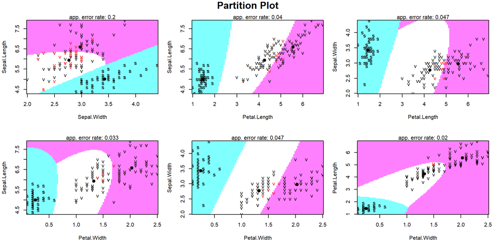

## Visualize LDA Results

```r
partimat(Species ~ ., data = iris, method = "lda")
```

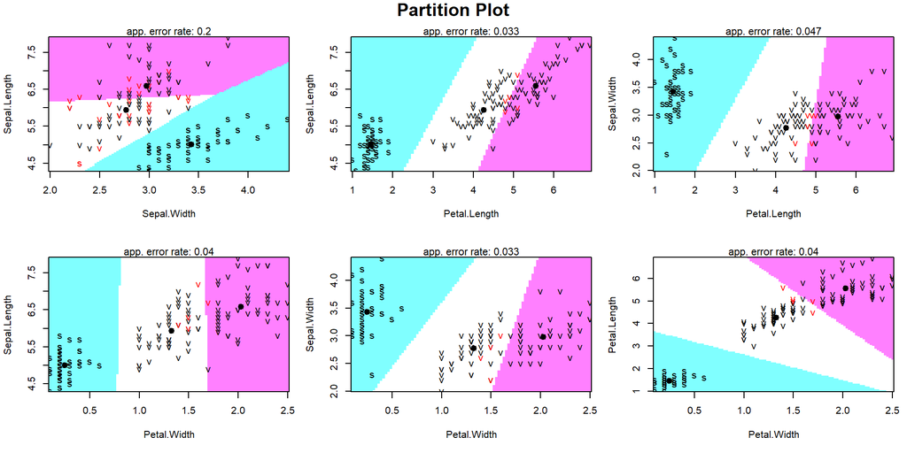

# Decision Theory

## Cost and Prior Probabilities

- Different types of errors might have different costs
- Prior probabilities are often available
- Goals:
  - When different errors have the same cost, we look for a classification rule that minimizes the probability of misclassification
  - When different errors cost differently, we want to find a classification rule that minimizes the total cost

# Equal Costs

## Minimize Probability of Misclassification

- Notations:
- $X$: data
- $Z$: true class. It is binary, i.e., $Z=1$ or $Z=0$
- $P(Z=1)=\pi$: prior probability, known
- $\delta(x)$: decision function / classifier
  - $\delta(x)=1$: allocate $x$ to group 1
  - $\delta(x)=0$: allocate $x$ to group 0

## Risk and Posterior Risk

- Risk of a classifier $\delta$
  $$\begin{aligned}
  R(\delta, z)&=\Pr [\delta(X)\not= Z|Z=z]=\mathbb E_{X|z} [\mathbb I_{\delta(X)\not= Z}|Z=z]\\
  &=\left\{
  \begin{array}{cc}
  \Pr[\delta(X)=0|z=1] & \mbox{ if } z=1\\
  \Pr[\delta(X)=1|z=0] & \mbox{ if } z=0
  \end{array}\right.
  \end{aligned}$$
- The posterior risk of $\delta$
  $$\begin{aligned}
  PR(\delta(x)) &= \Pr[\delta(x)\not= Z|x]=\mathbb E_{Z|x} [\mathbb I_{\delta(X)\not= Z}|X=x]\\
  &=\left\{
  \begin{array}{cc}
  \Pr[Z=0|x] & \mbox{ if } \delta(x)=1\\
  \Pr[Z=1|x] & \mbox{ if } \delta(x)=0
  \end{array}\right.
  \end{aligned}$$

## Bayes Risk

- Bayes risk $B(\delta)=\Pr [\delta(X)\not= Z]$.
- Note that
  $$B(\delta)=\Pr [\delta(X)\not= Z]=\mathbb E_{XZ} [\mathbb I_{\delta(X)\not= Z}]=E_X[PR(\delta, X)]=E_Z[R(\delta, Z)]$$
- Rewrite the Bayes risk
  $$\begin{aligned}
  B(\delta) &=\Pr [\delta(X)\not= Z]\\
  &=\Pr [\delta(X)=1, Z=0] + \Pr [\delta(X)=0, Z=1]\\
  &=\Pr [\delta(X)=1| Z=0]\Pr[Z=0] + \Pr [\delta(X)=0| Z=1] \Pr[Z=1]\\
  &=\pi \Pr [\delta(X)=0| Z=1]+ (1-\pi)\Pr [\delta(X)=1| Z=0]
  \end{aligned}$$
- The above expression is baesd on the fact
  $$B(\delta)=\mathbb E_{XZ} [\mathbb I_{\delta(X)\not= Z}]$$

## Bayes Classification Rule

- Want to find $\delta^*$ that minimizes $B(\delta)$
- Claim 1: the $\delta^*$ that minimizes $PR(\delta(x))$ also minimizes $B(\delta)$
  - This is because $B(\delta)=\mathbb E[PR(\delta(X)]\ge \mathbb E[PR(\delta^*(X)]=B(\delta^*)$]
- Need to find $\delta^*$ that minimizes $PR(\delta(x))$. It can be shown that

$$\delta^*(x)=\left\{
\begin{array}{cc}
1 & \mbox{ if } \frac{\Pr(Z=1|x)}{\Pr(Z=0|x)}>1\\
0 & \mbox{ if } \frac{\Pr(Z=1|x)}{\Pr(Z=0|x)}<1
\end{array}\right.$$

- Skip next slide if you are not interested in the proof

## The Classifier that Minimizes Posterior Risk

- Recall that
  $$PR(\delta(x)=0)=\Pr(Z=1|x), PR(\delta(x)=1)=\Pr(Z=0|x)$$
- Therefore, we $\delta^*(x)$ should be 1 if
  $$\begin{aligned}
  PR(\delta(x)=0)>PR(\delta(x)=1) &\Leftrightarrow \Pr(Z=1|x)> \Pr(Z=0|x)\\
  &\Leftrightarrow \frac{\Pr(Z=1|x)}{\Pr(Z=0|x)}>1
  \end{aligned}$$

## The Bayes Classification Rule

- We say $\delta^*(x)$ is the Bayes classification rule
  $$\delta^*(x)=\left\{
  \begin{array}{cc}
  1 & \mbox{ if } \frac{\Pr(Z=1|x)}{\Pr(Z=0|x)}>1\\
  0 & \mbox{ if } \frac{\Pr(Z=1|x)}{\Pr(Z=0|x)}<1
  \end{array}\right.$$
- Computation
  $$\begin{aligned}
  \frac{\Pr(Z=1|x)}{\Pr(Z=0|x)} &
  \overset{\mbox{Bayes' theorem}} = \frac{\frac{f(x|z=1)\Pr(Z=1)}{f(x)}}{\frac{f(x|z=0)\Pr(Z=0)}{f(x)}} = \frac{f(x|z=1)}{f(x|z=0)}\frac{\pi}{1-\pi}
  \end{aligned}$$
- A short review of Bayes’ theorem is on next slide. Feel free to skip if you are very familiar with it already

## Bayes’ Theorem

- Read this slide if you would like to review Bayes’ theorem
- Let $A$ and $B$ be two events.
- Bayes’ theorem says
  $$\Pr(B|A) = \dfrac{\Pr(A, B)}{\Pr(A)}=\dfrac{\Pr(A|B)\Pr(B)}{\Pr(A)}$$
  where $\Pr(A,B)$ means the joint probability that both $A$ and $B$ occur. We can use alternative expressions such as $\Pr(A \text{ and } B)$ and $\Pr(A \cap B)$.

## Example 1: Univariate

- Let’s consider a univariate example. Suppose that the population consists for two underlying populations
  - Population 1 with $\pi$ probability and $N(\mu_1=1, \sigma^2=0.25)$
  - population 0 with $1-\pi$ probability and $N(\mu_0=0, \sigma^2=0.25)$
- Would like to allocate $x=0.8$

### Example 1: Bayes Classification

- According to Bayes classification rule, we need to compute

$$\begin{aligned}
\frac{f(x|z=1)\pi}{f(x|z=0)(1-\pi)} &=\frac{f(x|\mu_1=1,\sigma^2)\pi}{f(x|\mu_0=0, \sigma^2)(1-\pi)}\\
&=\frac{\frac{1}{\sigma\sqrt{2\pi}}exp\{-\frac{1}{2\sigma^2}(x-1)^2\}}
{\frac{1}{\sigma\sqrt{2\pi}}exp\{-\frac{1}{2\sigma^2}(x-0)^2\}}\frac{\pi}{1-\pi}\\
&= exp\{\frac{1}{2\sigma^2} (2x-1) \}\frac{\pi}{1-\pi}
\end{aligned}$$

### Example 1: Classification Boundary

- The classification boundary is
  $$\begin{aligned}
  exp\{\frac{1}{2\sigma^2} (2x-1) \} =(1-\pi)/\pi &\Leftrightarrow \frac{1}{2\sigma^2} (2x-1)=log((1-\pi)/\pi)\\
  &\Leftrightarrow x=\sigma^2 log((1-\pi)/\pi)+0.5
  \end{aligned}$$
- The boundary is linear!
  - If $\pi=0.5$, the boundary is $x=0.5$, we classify $x=0.8$ to class 1.
  - If $\pi=0.7$, the boundary is $x=0.288$, we classify $x=0.8$ to class 1.
  - If $\pi=0.2$, the bondary is $x=0.846$, we classify $x=0.8$ to class 0.

### Example 1: Density and Classification Boundary

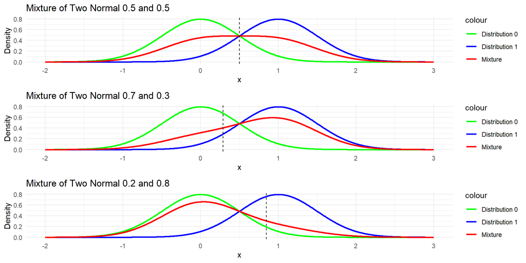

## Example 2: Multivariate

- For a two-class problem, the classification boundary by Bayes’ classification rule is
  $$\frac{f(x|z=1)\pi}{f(x|z=0)(1-\pi)}=1\\
  \Leftrightarrow log(\frac{f(x|z=1)}{f(x|z=0)})=log(\frac{1-\pi}{\pi})$$

### Example 2: Bayes’ Classification under Equal Covariance

- Suppose the two underlying distributions are $N(\boldsymbol\mu_1, \boldsymbol \Sigma)$ and $N(\boldsymbol\mu_2, \boldsymbol \Sigma)$.
- The boundary is
  $$-\frac{1}{2}(x-\boldsymbol\mu_1)^T \boldsymbol\Sigma^{-1}(x-\boldsymbol\mu_1) + \frac{1}{2}(x-\boldsymbol\mu_1)^T \boldsymbol\Sigma^{-1}(x-\boldsymbol\mu_1)\\
  =log(\frac{1-\pi}{\pi})$$
  which is equivalent to

$$(\boldsymbol\mu_1 -\boldsymbol\mu_2)^T \boldsymbol\Sigma^{-1}x = (\boldsymbol\mu_1 -\boldsymbol\mu_2)^T\boldsymbol\Sigma^{-1}\frac{\boldsymbol\mu_1 + \boldsymbol\mu_2}{2} + log(\frac{1-\pi}{\pi})$$

### Example 2: Bayes’ Classification under Equal Covariance

- In practice, we substitute the unknown parameters by their estimates
  $$(\bar {\mathbf X}_{1.} -\bar {\mathbf X}_{2.})^T\boldsymbol\Sigma^{-1}x = (\bar {\mathbf X}_{1.} -\bar {\mathbf X}_{2.})^T \boldsymbol\Sigma^{-1}\frac{\bar {\mathbf X}_{1.} + \bar {\mathbf X}_{2.}}{2} + log(\frac{1-\pi}{\pi})$$
- Recall that in LDA the linear boundary is
  $$a^Tx=a^T\frac{\bar {\mathbf X}_{1.} + \bar {\mathbf X}_{2.}}{2}$$
  Therefore, Bayes’ classification is the same as the LDA when $\pi=1/2$.
- Similarly, in a g-class problem, LDA is the same as Bayes classification under the assumptions (1) multivariate normality, (2) equal covariance, and (3) uniform prior probabilities.

## Connection with Logistic Regression

- Under the Bayes rule, LDA computes the posterior odds
  $$\frac{\Pr(Z=1|x)}{{\Pr(Z=0|x)}}$$
- The logarithm of the posterior odds is called the log-odds or logit:

$$log\frac{\Pr(Z=1|x)}{{\Pr(Z=0|x)}}$$

- For LDA, the log-posterior odds is a linear function of the covariates.

### Logistic Regression

- The logistic regression is a popular method for binary classification and modeling binary response variables.
- It models the conditional probability
  $$Pr(Z=1|x)$$
  as a function of the covariates.
- The logit function is defined as
  $$logit(p) = log \frac{p}{1-p}$$

A logistic regression models the log-odds as a linear function of the covariates:
$$log\frac{\Pr(Z=1|x)}{{\Pr(Z=0|x)}} = \beta^T x$$

### Connection with Logistic Regression

- In both approaches, the decision function is a linear function of the covariates.
- They also give similar results.
- The two approaches were derived from different models with different assumptions.
  - Logistic regression models the conditional distribution of the response given the covariates: $Pr(Z|x)$
  - LDA models the distribution of the covariates within each class: $f(x|z)$.
- Under the multivariate normal assumption with a common covariance matrix, LDA implies a logistic form for the posterior probability.
- If the multivariate normal assumption is violated, logistic regression is often more robust and may perform better.

## Example 3: Univariate, Unequal Variance

- Again, consider a univariate example. This time we relax the assumption of equal variance
  - Population 1 with $\pi$ probability and $N(\mu_1=1, \sigma_1^2=0.25)$
  - population 0 with $1-\pi$ probability and $N(\mu_0=0, \sigma_2^2=0.64)$
- Would like to allocate $x=0.8$

### Example 3: Bayes Classification

- According to Bayes classification rule, we need to compute
  $$\begin{aligned}
  &\frac{f(x|z=1)\pi}{f(x|z=0)(1-\pi)}\\ &=\frac{f(x|\mu_1=1,\sigma_1^2)\pi}{f(x|\mu_0=0, \sigma_0^2)(1-\pi)}\\
  &=\frac{\frac{1}{\sigma_1\sqrt{2\pi}}exp\{-\frac{1}{2\sigma_1^2}(x-1)^2\}}
  {\frac{1}{\sigma_0\sqrt{2\pi}}exp\{-\frac{1}{2\sigma_0^2}(x-0)^2\}}\frac{\pi}{1-\pi}\\
  &= exp\{(\frac{1}{2\sigma_0^2}-\frac{1}{2\sigma_1^2})x^2 + \frac{x}{\sigma_1^2}-\frac{1}{2\sigma_1^2}\}
  \frac{\pi}{1-\pi}\frac{\sigma_0}{\sigma_1}
  \end{aligned}$$

### Example 3: Classification Boundary

- The classification boundary is
  $$(\frac{1}{2\sigma_0^2}-\frac{1}{2\sigma_1^2})x^2 + \frac{x}{\sigma_1^2}-\frac{1}{2\sigma_1^2}=log[
  \frac{1-\pi}{\pi}\frac{\sigma_1}{\sigma_0}]$$
- It is quadratic!
- In this problem, $\sigma_0=0.8, \sigma_1=0.5, \mu_1=1, \mu_0=0$. We allocate to 1 if
  $$(\frac{1}{1.28}-\frac{1}{0.5})x^2 + \frac{x}{0.25}-\frac{1}{0.5}>log[
  \frac{0.5}{0.5}\frac{0.5}{0.8}]$$

### Example 3: Visualize the result

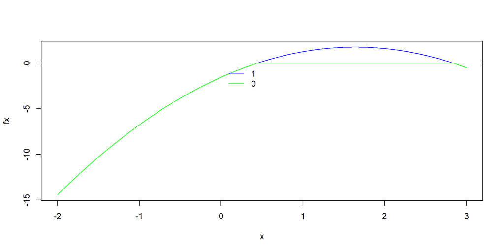

# Unequal Costs

## Risk and Cost

- Different types of misclassifications might cost differently
- Let $L(\delta(x), z)$ denote the cost function
- Let $C(1|0)=L(1, 0)$, the cost of misclassifying 0 to 1
- Let $C(0|1)=L(0, 1)$, the cost of misclassifying 1 to 0
- The Risk and Bayes risk need to be revised accordingly

## Risk and Posterior Risk

- Risk of a classifier $\delta$
  $$\begin{aligned}
  R(\delta, z)&=\mathbb E_{X|Z=z} [L(\delta(X), z)]\\
  &=\left\{
  \begin{array}{cc}
  C(0|1)\Pr[\delta(X)=0|z=1] & \mbox{ if } z=1\\
  C(1|0)\Pr[\delta(X)=1|z=0] & \mbox{ if } z=0
  \end{array}\right.
  \end{aligned}$$
- The posterior risk of $\delta$
  $$\begin{aligned}
  PR(\delta(x)) &= \mathbb E_{Z|x}[L(\delta(x), Z)]\\
  &=\left\{
  \begin{array}{cc}
  C(1|0)\Pr[Z=0|x] & \mbox{ if } \delta(x)=1\\
  C(0|1)\Pr[Z=1|x] & \mbox{ if } \delta(x)=0
  \end{array}\right.
  \end{aligned}$$

## Bayes Risk

- Bayes risk
  $$B(\delta)=\mathbb E_{XZ} [L(\delta(X), Z)]$$
- Rewrite the Bayes risk

$$\begin{aligned}
B(\delta) &=\mathbb E_{XZ} [L(\delta(X), Z)]\\
&=L(\delta(X)=1, Z=0)\Pr[\delta(X)=1, Z=0] + L(\delta(X)=0, Z=1)[\delta(X)=0, Z=1]\\
&=C(1|0)\Pr [\delta(X)=1, Z=0] + C(0|1)\Pr [\delta(X)=0, Z=1]\\
&=C(1|0)\Pr [\delta(X)=1| Z=0]\Pr[Z=0] + C(0|1)\Pr [\delta(X)=0| Z=1] \Pr[Z=1]\\
&=C(0|1)\pi \Pr [\delta(X)=0| Z=1]+ (1-\pi)C(1|0)\Pr [\delta(X)=1| Z=0]
\end{aligned}$$

## Bayes Classification Rule with Unequal Costs

- Use a derivation similar to the equal cost situation, we can show that the Bayes classification rule is

$$\begin{aligned}
&PR(\delta(x)=0)>PR(\delta(x)=1) \\
&\Leftrightarrow C(0|1)\Pr(Z=1|x)> C(1|0)\Pr(Z=0|x)\\
&\Leftrightarrow \frac{\Pr(Z=1|x)}{\Pr(Z=0|x)}>\frac{C(1|0)}{C(0|1)}\\
&\Leftrightarrow \frac{f(x|z=1)}{f(x|z=0)}>\frac{C(1|0)}{C(0|1)}\frac{1-\pi}{\pi}
\end{aligned}$$

# Other Related Topics

- There are numerous issues/methods / models
- Training error vs testing error
- Model / variable selection / shrinkage
- Classification tree. Random forest
- Support vector machine
- Neural network and deep neural network